# NDVI

### Splitting by province and calculating the weights

Next, we need to split the raster file using the polygons of the province. Let’s download the polygons of the provinces from [GADM](https://gadm.org):

```r
download.file("https://biogeo.ucdavis.edu/data/gadm3.6/Rsp/gadm36_VNM_1_sp.rds", "provinces.rds")
```

Loading them into R:

```r
provinces <- readRDS("provinces.rds")
```

Again, let’s check it’s the same projection:

```r
projection(provinces)
```

```
## [1] "+proj=longlat +datum=WGS84 +no_defs +ellps=WGS84 +towgs84=0,0,0"
```

and:

```r
unique(sapply(ndvi, projection))
```

```
## [1] "+proj=longlat +datum=WGS84 +no_defs +ellps=WGS84 +towgs84=0,0,0"
```

and:

```r
unique(sapply(wp, projection))
```

```
## [1] "+proj=longlat +datum=WGS84 +no_defs +ellps=WGS84 +towgs84=0,0,0"
```

OK. Now, let’s compute provinces’ masks:

```r
wpop <- wp[[1]]
prov_masks <- lapply(seq_along(provinces), function(x) rasterize(provinces[x, ], crop(wpop, provinces[x, ])))
```

The following function calculates the weights, using the masks:

```r
calc_weights <- function(prov_mask, wpop) {
  wpop_val <- values(mask(crop(wpop, prov_mask), prov_mask))
  wpop_val / sum(wpop_val, na.rm = TRUE)
}
```

where `prov_mask` is a province mask and `wpop` is a WorldPop raster. Now, we can calculate the weights (takes about 1’30’’):

```r
weights <- parallel::mclapply(wp, function(x) lapply(prov_masks, calc_weights, x), mc.cores = 4)
```

## Aggregating

Let’s now use these weights together with the `ndvi` rasters to compute NDVI values by province. As above, we first need to split NDVI rasters by province, which is what the following function does:

```r
separate_by_province <- function(prov_mask, ndvi) {
  values(mask(crop(ndvi, prov_mask), prov_mask))
}
```

Let’s use this function to separate the NDVI files by province (takes about 17’-18’):

```r
ndvi2 <- parallel::mclapply(ndvi, function(x) lapply(prov_masks, separate_by_province, x), mc.cores = 4)
```

```r
weights2 <- rep(c(weights[c(1, 1)], weights), each = 12)
```

Let’s compute:

```r
ndvi3 <- purrr::map2(ndvi2, weights2, purrr::map2, function(x, y) sum(x * y, na.rm = TRUE)) %>%
  lapply(setNames, provinces$VARNAME_1) %>%
  dplyr::bind_rows(.id = "date") %>%
  tidyr::separate(date, c("year", "month", "day"), c(4, 6)) %>%
  dplyr::select(-day) %>%
  dplyr::mutate_at(c("year", "month"), as.integer) %>%
  dplyr::arrange(year, month) %>%
  dplyr::mutate(month = as.ordered(month.name[month])) %>%
  tidyr::pivot_longer(-tidyselect::any_of(c("year", "month")), names_to = "province", values_to = "ndvi")
```

Let’s have a look:

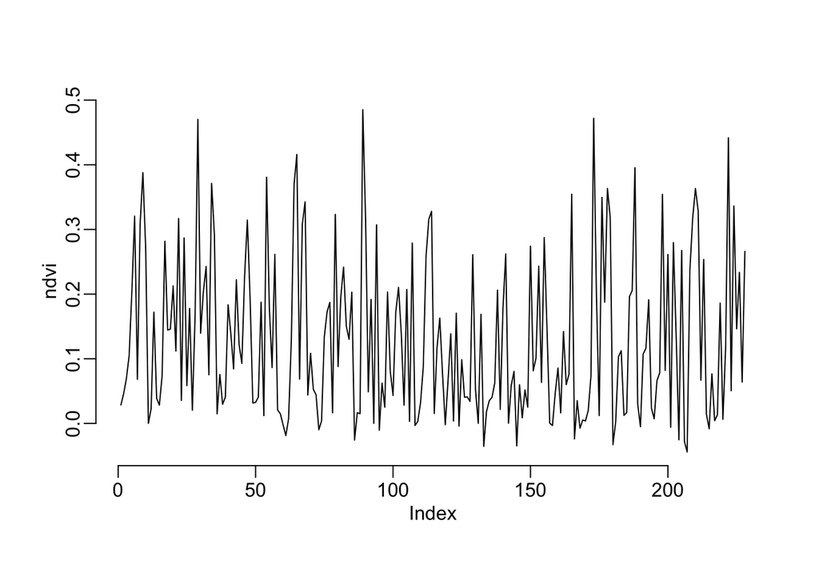

```r
ndvi3 %>%
  dplyr::filter(province == "Ha Noi") %$%
  plot(ndvi, type = "l")
```